# Soc. 723 HW due 1.16.22

Brenda Onyango

1/9/2022

## Chapter 3 Homework

1. What is a variable? A variable is a characteristic that takes on different values across a unit of analysis. In the chapter monthly incomes of 433 South Africans was given as a variable, but it would be more precise to say that monthly income is the variable measured at the unit of the individual and that there are 433 observations for this variable.
2. For each of the following variables describe if it is continuous, count, ordinal, categorical or qualitative.
1. Age - continuous*
2. gender - categorical
3. number of times of presidential tweets - count
4. income - continuous
5. number of Insta posts about stats - count
6. college students’ attend - categorical
7. therapist’s written assessment - qualitative
8. soccer divisions - ordinal

*Technically continuous but I know practically for data analyses age is often treated as discrete.

3. distribution

### Frequency Table

Before answering 4, I created an object with given data to do some visualization and calculate relative frequencies.

```r
#create table with salaries and frequency

salaryset <- c(rep('85K', 5), rep('90K', 4), rep('100K', 1), rep('120K', 2),
rep('125K', 3), rep('130K', 2))

salarytable <- table(salaryset)
```

Let’s look at the table.

```r
salarytable #notice that R arranged in different order than what was entered in set
```

```
## salaryset
## 100K 120K 125K 130K  85K  90K
##    1    2    3    2    5    4
```

```r
#constructing relative frequency distribution of the data in the table.

s <- sum(salarytable)

#divide by sum to get relative frequencies
relfreq <- salarytable/s

#view freq
relfreq
```

```
## salaryset
##       100K       120K       125K       130K        85K        90K
## 0.05882353 0.11764706 0.17647059 0.11764706 0.29411765 0.23529412
```

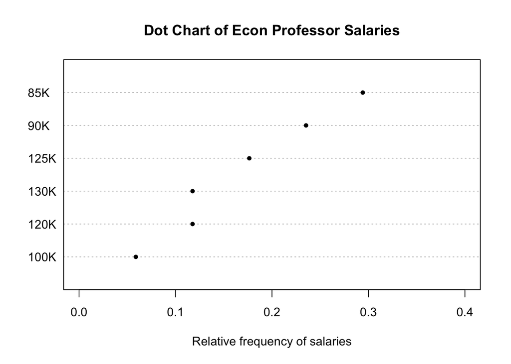

```r
dotchart(sort(relfreq),
         xlab = 'Relative frequency of salaries',
         main = 'Dot Chart of Econ Professor Salaries',
         xlim = c(0, 0.4), pch = 20, color = 'black')
```

1. Calculate average salary.

```r
salaries <- c(rep(85000, 5), rep(90000, 4), rep(100000, 1), rep(120000, 2),
rep(125000, 3), rep(130000, 2))

head(salaries, 9) #confirming data entered correctly. Note that salaries is numerical and salaryset is categorical.
```

```
## [1] 85000 85000 85000 85000 85000 90000 90000 90000 90000
```

```r
mean(salaries)
```

```
## [1] 103529.4
```

Average salary is $103,529.40.

2. Find median.

```r
median(salaries)
```

```
## [1] 90000
```

The median is $90,000.

3. Find min and max.

```r
min(salaries)
```

```
## [1] 85000
```

```r
max(salaries)
```

```
## [1] 130000
```

Min is 85,000 & max is $130,000. Instead of using min() and max(), I could have looked at the table.

4. Find IQR.

```r
IQR(salaries) #IQR is 40,000
```

```
## [1] 40000
```

```r
summary(salaries) #quartiles
```

```
##    Min. 1st Qu.  Median    Mean 3rd Qu.    Max.
##   85000   85000   90000  103529  125000  130000
```

5. 3. Greek letters
6. 1. Log transforming the variable
7. Order from *low* to *high* variability: D, A, C, B